# L10 - Estimation

## Lecture Goals

- Understand fundamentals of statistical estimation
  - Sampling distribution
  - Point & interval estimates
- Apply resampling methods for estimation
  - Bootstrap confidence intervals
- Readings
  - [ISRS](https://www.openintro.org/download.php?file=isrs1_tablet&referrer=/stat/textbook.php): ch. 4.5
  - [ModernDive](https://moderndive.com/9-confidence-intervals.html): ch. 9

## Estimation

- Interested in **estimating** value of parameter based on sample
- Specific sample gives *one* out of all possible statistic values

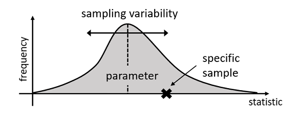

## Estimation

- In reality, don't know **sampling distribution**, i.e. how statistic values are dispersed

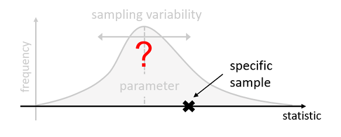

- Can only control two things
  - *Sampling method*: randomness prevents bias
  - *Sample size*: higher \(n\) improves accuracy

## Labour Force Survey Data

- [*Labour Force Survey*](https://www150.statcan.gc.ca/n1/pub/71-543-g/71-543-g2018001-eng.htm) (LFS): monthly survey providing crucial employment information
  - Used to calculate *unemployment rates*
- Access [LFS *microdata*](http://sda.chass.utoronto.ca/sdaweb/html/lfs.htm) (individual responses) through UofT's [CHASS Data Centre](http://datacentre.chass.utoronto.ca/)
- File `LFS_Toronto.csv` contains 2018 LFS data for Toronto's Census Metropolitan Area (CMA)

```r
lfs = read_csv('./data/LFS_Toronto.csv')
```

## Example

- Estimate Toronto unemployment rate: \(\frac{\textrm{# unemployed}}{\textrm{# labour force}}\)
- Employment status given by variable `lfsstat`
  - 1, 2: employed (working/on leave)
  - 3: unemployed
  - 4: Not in labour force

```r
lfs %>% summarise( UNEMPL = sum(lfsstat == 3) / sum(lfsstat != 4) )
```

```
## # A tibble: 1 x 1
##   UNEMPL
##    <dbl>
## 1 0.0619
```

## Estimation

- Statistic gives *single value*, a.k.a. **point estimate**
- Point estimates don't convey information about *accuracy*
  - How close to parameter do we *expect* statistic to be?
  - Need information on *sampling distribution/variability*
- Two ways to assess sampling distribution
  - *Analytical*: uses Probability Theory
  - *Resampling*: uses sampling from the sample

## Bootstrap

- **Bootstrap method**: resample original SRS sample, where
  - Each resample has **same size** as original sample
  - Each resample is randomly selected **with replacement**

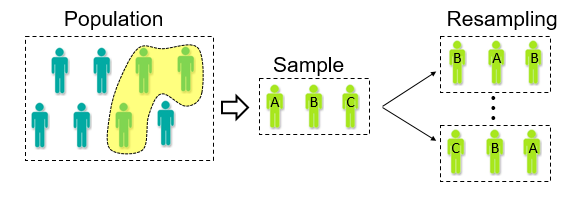

- Calculate statistic for each bootstrap sample (i.e. resample), and treat them as values from sampling distribution

## Example

- Use `infer` package to bootstrap data-frames
  - `specify()` selects variable(s)
  - `generate()` resamples data
  - `calculate()` calculates statistic

```r
library(infer)
lfs_boot = lfs %>% filter( lfsstat %in% 1:3) %>%
  mutate( unemployed = (lfsstat == 3) ) %>%
  specify( response = unemployed, success = "TRUE" ) %>%
  generate( reps = 500, type = "bootstrap" ) %>%
  calculate( stat = "prop" ) %>% rename( UNEMPL = stat )
save(lfs_boot, file = "./data/lfsboot.R")
```

## Example

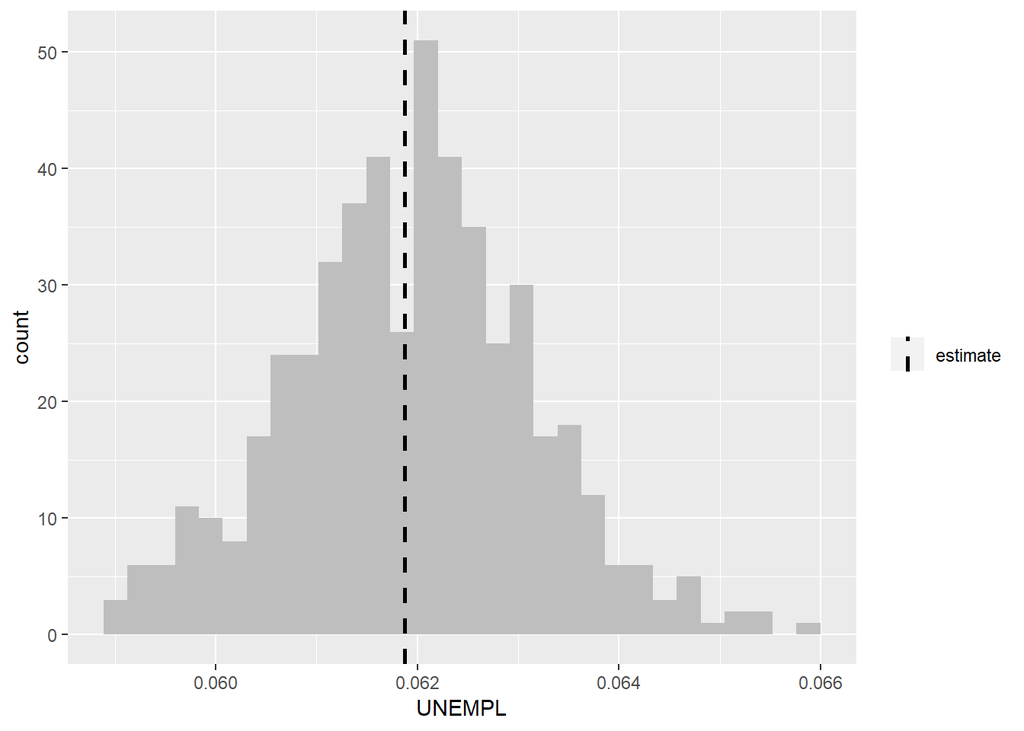

## Confidence Intervals

- **Confidence Interval** (CI): interval computed based on sample in such a way that it *contains* parameter for specific *proportion* of all samples
- **Confidence level**: proportion of samples whose interval contains parameter
  - Controls CI *width*; typically set at 95%

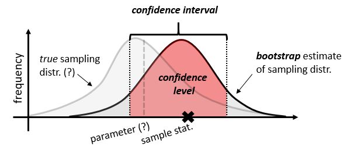

## Example

- 95% CI for Toronto unemployment rate

```r
(CI = lfs_boot %>% summarise( lower = quantile(UNEMPL, .025),
                              upper = quantile(UNEMPL, .975)))
```

```
## # A tibble: 1 x 2
##    lower  upper
##    <dbl>  <dbl>
## 1 0.0595 0.0645
```

## Example

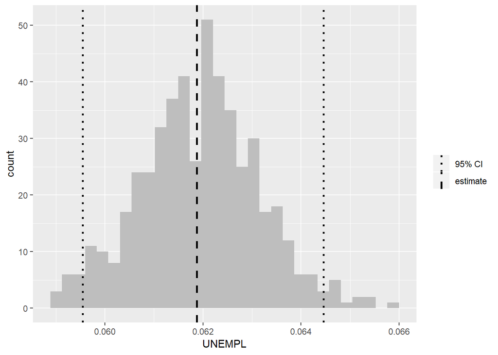

## CI's and Standard Errors

- Most sampling distributions are symmetric with single peak around mean
- In such cases, common to construct CI as: \(\textrm{point estimate }\pm\textrm{ margin of error}\)
  - **Margin of error** (CI half-width) reflects estimation accuracy
- For 95% confidence level, margin of error is *approximately* twice the **standard error** (SE)
  - SE given by *standard deviation* of bootstrap samples, which measures the "average distance" from their mean

## Example

- 95% CI for Toronto unemployment rate

```r
# margin of error
(ME = (CI$upper - CI$lower)/2)
##       97.5%
## 0.002455526

# standard error
(SE = sd( lfs_boot$UNEMPL ))
## [1] 0.001206671
2*SE
## [1] 0.002413342
```

## Example

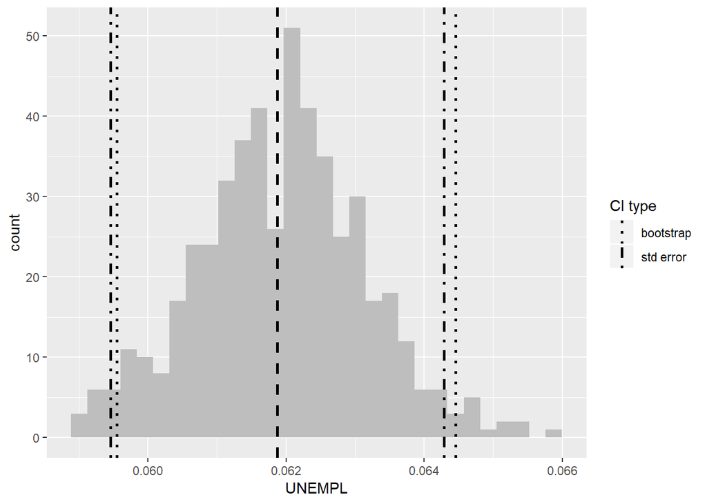